# Forecasting Office Rental Market in Melbourne CBD

# 1 Describing Office Rental Data

## 1.1 Rent Levels

The below graph shows the office rental prices in Melbourne CBD in three classes. The highlights in the series are 1. a long period of decline in 90s. 2. a short priod of decline over 2002-2004. 3. The market has not been effeced by global financial crisis over 2007-2008.

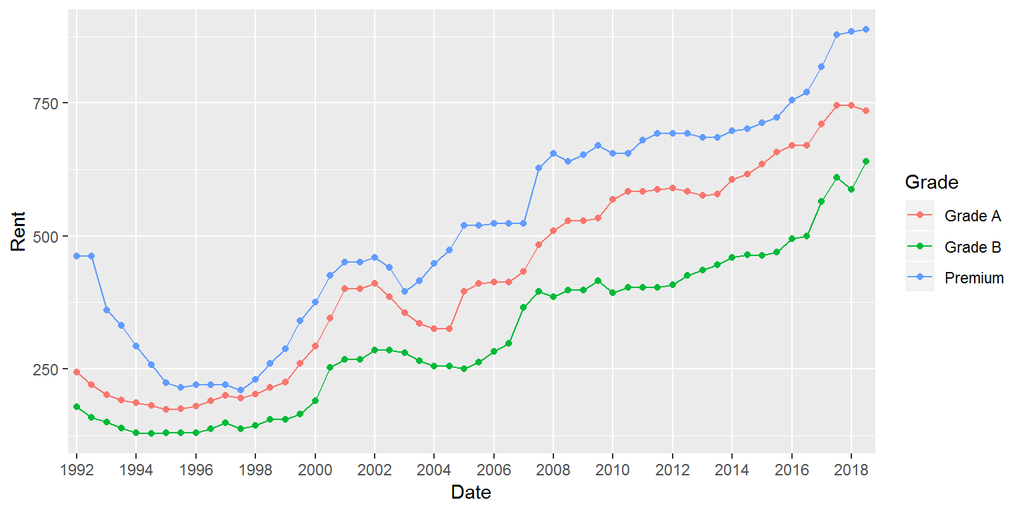

|  | Mean | Std.Dev. | Min | Q1 | Median | Q3 | Max | N |
| --- | --- | --- | --- | --- | --- | --- | --- | --- |
| Premium | 519 | 199 | 210 | 363.75 | 520 | 685.00 | 888 | 54 |
| Grade.A | 424 | 183 | 173 | 229.75 | 410 | 583.00 | 745 | 54 |
| Grade.B | 314 | 145 | 128 | 159.75 | 284 | 413.25 | 640 | 54 |

## 1.2 Rent Growth

The interesting point regarding the rental market is that the less quality properties (Grade B) have had the most growth rate in the market, and the luxury ones (Premium) have experienced the least growth.

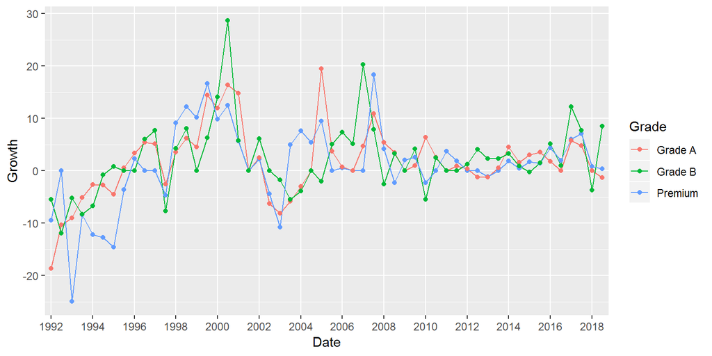

|  | Mean | Std.Dev. | Min | Q1 | Median | Q3 | Max | N |
| --- | --- | --- | --- | --- | --- | --- | --- | --- |
| Premium | 1.03 | 7.58 | -24.95 | 0.00 | 0.68 | 4.79 | 18.30 | 54 |
| Grade.A | 1.70 | 6.61 | -18.64 | -1.20 | 0.90 | 4.69 | 19.51 | 54 |
| Grade.B | 2.27 | 6.83 | -11.92 | -0.64 | 1.12 | 5.62 | 28.64 | 54 |

## 1.3 Office Market Data

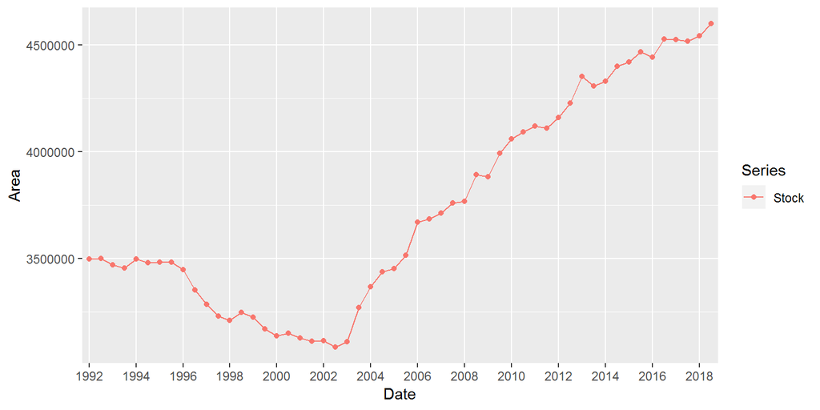

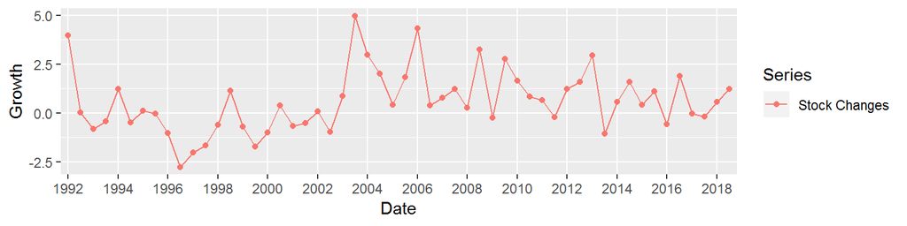

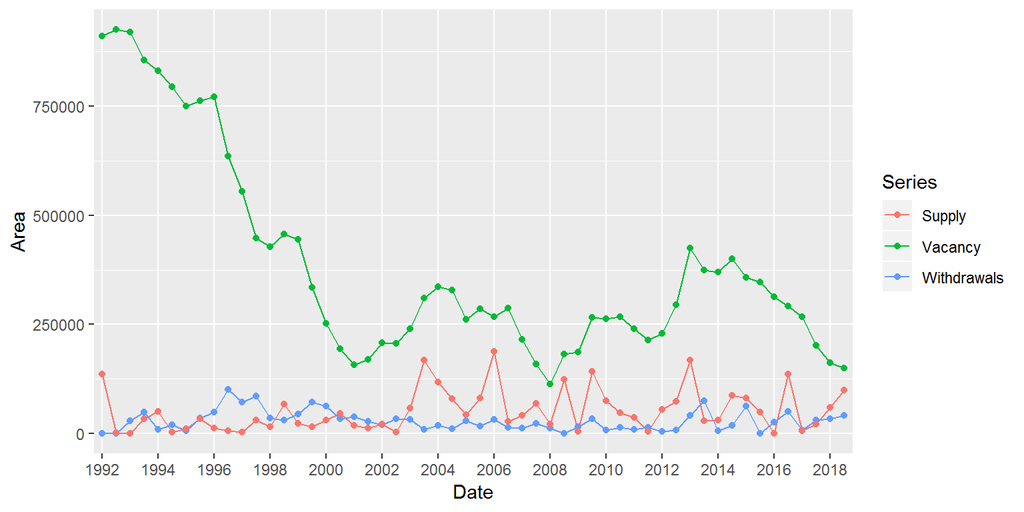

|  | Mean | Std.Dev. | Min | Q1 | Median | Q3 | Max | N |
| --- | --- | --- | --- | --- | --- | --- | --- | --- |
| Stock | 3730.85 | 492.08 | 3084.85 | 3301.26 | 3507.12 | 4150.31 | 4598.48 | 54 |
| Stock Change (%) | 0.58 | 1.58 | -2.77 | -0.51 | 0.41 | 1.24 | 4.96 | 54 |
| Vacancy | 381.84 | 229.83 | 113.21 | 219.45 | 293.95 | 440.10 | 925.11 | 54 |
| Vacancy (%) | 10.65 | 6.90 | 3.00 | 6.00 | 8.00 | 13.75 | 27.00 | 54 |
| Supply | 51.96 | 48.37 | 0.00 | 15.37 | 35.25 | 74.14 | 187.83 | 54 |
| Withdrawals | 29.07 | 23.07 | 0.00 | 11.54 | 27.34 | 38.22 | 100.47 | 54 |

## 1.4 Decomposition of Rent Series

### 1.4.1 Autocorrelation

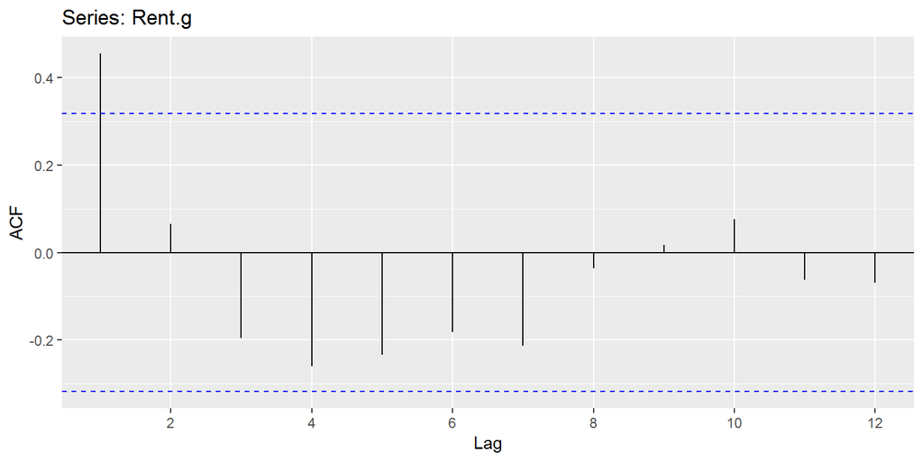

### 1.4.2 Seasonal Effects

A plot that emphasises the seasonal patterns is where the data for each season are collected together in separate mini time plots. The horizontal lines indicate the means for each month. This form of plot enables the underlying seasonal pattern to be seen clearly, and also shows the changes in seasonality over time. It is especially useful in identifying changes within particular seasons. In our case, the plot is not particularly revealing; we should be careful and consider the non-trivial effects preceived.

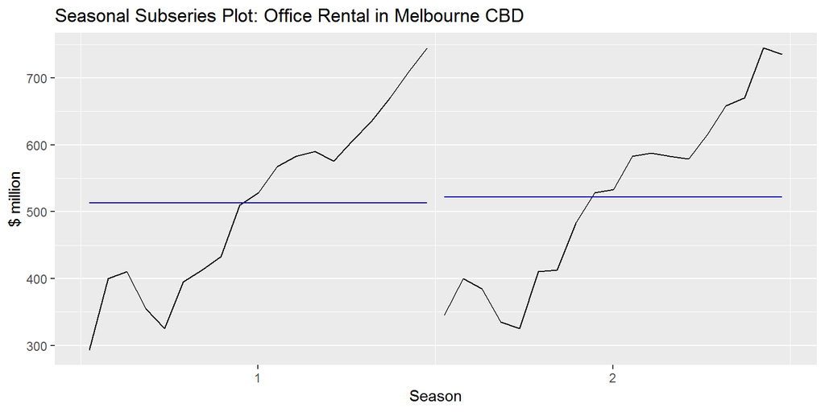

### 1.4.3 Time-Series Decomposition

A time series decomposition can be used to measure the strength of trend and seasonality in a time series (Wang, Smith, & Hyndman, 2006). The classical decomposition method originated in the 1920s. It is a relatively simple procedure, and forms the starting point for most other methods of time series decomposition. There are two forms of classical decomposition: an additive decomposition and a multiplicative decomposition. In classical decomposition, we assume that the seasonal component is constant from year to year. For multiplicative seasonality, the m values that form the seasonal component are sometimes called the “seasonal indices”.

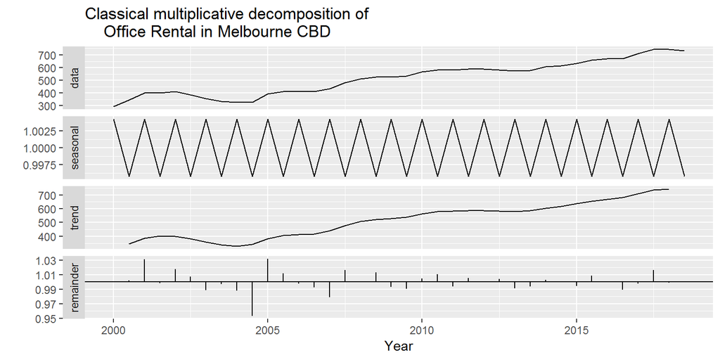